# Exploratory Data Analysis

2026-11-06

## Loading dataset

```r
load("12_DataSaving.RData")
source("00_requirements.R")
source("03_funct_EDA.R")
```

## SECTION 1

## Screening of Prolonged Pain or Stiffness, Frequencies, and Physical Measurements

The research question to answer is the following:

During the 2009-2010 NHANES survey cycle, among NHANES participants from ages 20-69, are reported pain regions associated with differences observed in spinal mobility measurements?

From what we learned from data cleaning, we hold categories of variables pertaining to different survey coverage concerns from the NHANES datasets. - Criteria Variables: Some variables were aimed to test for eligibility with further-symptom questions. - Pain Regions: Variables listing the reported locations participants were experiencing pain. - Symptom Descriptions: Variables reported from patients describing their symptoms, such as when they occurred and what may have influenced them. - Physical Examinations: Measurement variables collected from the NHANES survey such as lumbar flexion, chest expansion and others. - Demographic Characteristics and Others: Broad variables for subgroup analysis such as ethnicity, BMI, sex, age, height and weight.

To answer the research question, we’ll need to learn how we should be perceiving the data pertaining to pain and spinal mobility, as well as any caveats that may challenge existing medical assumptions related to the question.

## Overview

```r
dim(clean_data)
```

```
## [1] 5001   37
```

```r
names(clean_data)
```

```
##  [1] "id"                     "symptoms_asked"         "back_pain"
##  [4] "site_neck"              "site_upper_back"        "site_mid_back"
##  [7] "site_low_back"          "site_buttocks"          "site_hip"
## [10] "site_rib_cage"          "morning_stiffness"      "pain_during_day"
## [13] "pain_with_rest"         "pain_wakes_at_night"    "wakes_after_4_hours"
## [16] "better_with_exercise"   "buttock_pain_switches"  "heel_pain"
## [19] "ulcerative_colitis"     "crohns_disease"         "ankylosing_spondylitis"
## [22] "exam_status"            "occiput_wall_cm"        "chest_inhale_cm"
## [25] "chest_exhale_cm"        "chest_expansion_cm"     "lumbar_flexion_cm"
## [28] "age_years"              "sex"                    "race_ethnicity"
## [31] "pregnancy_status"       "height_cm"              "weight_kg"
## [34] "bmi"                    "exam_weight"            "survey_psu"
## [37] "survey_stratum"
```

## Intro Pain Survey Checks

```r
table(clean_data$back_pain, useNA = "ifany")
```

```
##
##  Yes   No <NA>
## 1483 3516    2
```

It appears that around 29.7% of the survey has reported symptoms of pain, aching or stiffness in regions like the back, neck and hip over the course of 6 weeks, daily. Those who said ‘no’ are not to be treated as having no symptoms, for they simply didn’t meet the criteria for answering ‘yes’ with this question. It provides a considerable threshold to potentially stratify participants by back pain.

For clarification with the measurement examinations:

Lumbar flexion is measuring the increase in distance between two lower-back marks when bending forward. Higher lumbar flexion is generally better.  
Chest expansion is the difference between chest circumference at full inspiration and expiration when breathing. Higher chest expansion is generally better.  
Occiput-to-wall is the distance between the back of the head and the wall when standing upright. Lower measurements are generally better.

## Between ‘yes’ and ‘no’ participants, how do specific measurements differ?

```r
sum(is.na(clean_data$back_pain))
```

```
## [1] 2
```

Only 2 participants have NA here, so it’s relatively negligible for the following checks.

```r
yes_group <- clean_data[clean_data$back_pain == "Yes", ]
no_group  <- clean_data[clean_data$back_pain == "No", ]

cat("Yes Group - LUMBAR FLEXION\n")
```

```
## Yes Group - LUMBAR FLEXION
```

```r
summary(yes_group$lumbar_flexion_cm)
```

```
##    Min. 1st Qu.  Median    Mean 3rd Qu.    Max.    NA's
##   0.000   3.000   3.800   3.847   4.700  10.500     112
```

```r
cat("No Group - LUMBAR FLEXION\n")
```

```
## No Group - LUMBAR FLEXION
```

```r
summary(no_group$lumbar_flexion_cm)
```

```
##    Min. 1st Qu.  Median    Mean 3rd Qu.    Max.    NA's
##   0.400   3.000   3.800   3.919   4.700  11.000     228
```

```r
cat("Yes Group - CHEST EXPANSION\n")
```

```
## Yes Group - CHEST EXPANSION
```

```r
summary(yes_group$chest_expansion_cm)
```

```
##    Min. 1st Qu.  Median    Mean 3rd Qu.    Max.    NA's
##   0.000   3.000   4.100   4.385   5.500  15.000     120
```

```r
cat("No Group - CHEST EXPANSION\n")
```

```
## No Group - CHEST EXPANSION
```

```r
summary(no_group$chest_expansion_cm)
```

```
##    Min. 1st Qu.  Median    Mean 3rd Qu.    Max.    NA's
##   0.300   3.200   4.400   4.605   5.900  18.500     270
```

```r
cat("Yes Group - OCCIPUT-TO-WALL\n")
```

```
## Yes Group - OCCIPUT-TO-WALL
```

```r
summary(yes_group$occiput_wall_cm)
```

```
##    Min. 1st Qu.  Median    Mean 3rd Qu.    Max.    NA's
##  0.0000  0.0000  0.0000  0.3163  0.0000 11.4000      21
```

```r
cat("No Group - OCCIPUT-TO-WALL\n")
```

```
## No Group - OCCIPUT-TO-WALL
```

```r
summary(no_group$occiput_wall_cm)
```

```
##    Min. 1st Qu.  Median    Mean 3rd Qu.    Max.    NA's
##  0.0000  0.0000  0.0000  0.2485  0.0000 16.5000      46
```

Based on summaries alone, it seems that lumbar flexion between the two groups is quite similar; yielding the same IQR and medians. The means differ by 0.072. Chest expansion has a mean difference of 0.220, with summary returns being larger in the No Group. Occiput-To-Wall groups have the same medians, but the Yes-Group has a larger mean.

In regards to the research question, associations may be measurement-specific, as opposed to a global shift in physical examinations.

## Addressing the NAs

```r
mean(is.na(yes_group$lumbar_flexion_cm)) * 100
```

```
## [1] 7.542088
```

```r
mean(is.na(no_group$lumbar_flexion_cm)) * 100
```

```
## [1] 6.480955
```

```r
mean(is.na(yes_group$chest_expansion_cm)) * 100
```

```
## [1] 8.080808
```

```r
mean(is.na(no_group$chest_expansion_cm)) * 100
```

```
## [1] 7.674815
```

```r
mean(is.na(yes_group$occiput_wall_cm)) * 100
```

```
## [1] 1.414141
```

```r
mean(is.na(no_group$occiput_wall_cm)) * 100
```

```
## [1] 1.307561
```

Between the groups, despite NA values existing, their proportions of missing observations were relatively similar. Overall, it’s not too imbalanced, but that doesn’t rule out potential significance later on.

Let’s examine the variables as boxplots:

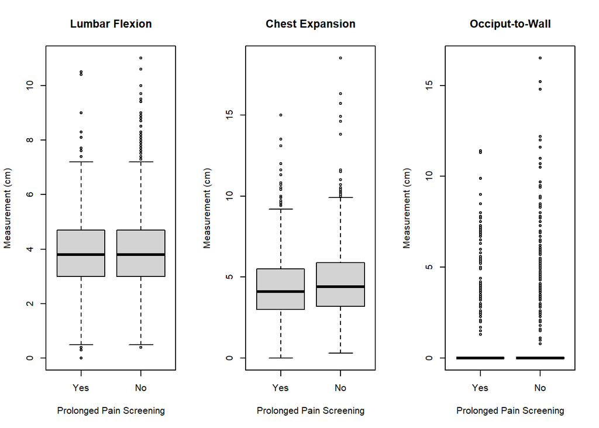

```r
par(mfrow = c(1, 3))

boxplot(yes_group$lumbar_flexion_cm,
        no_group$lumbar_flexion_cm,
        names = c("Yes", "No"),
        main = "Lumbar Flexion",
        ylab = "Measurement (cm)",
        xlab = "Prolonged Pain Screening")

boxplot(yes_group$chest_expansion_cm,
        no_group$chest_expansion_cm,
        names = c("Yes", "No"),
        main = "Chest Expansion",
        ylab = "Measurement (cm)",
        xlab = "Prolonged Pain Screening")

boxplot(yes_group$occiput_wall_cm,
        no_group$occiput_wall_cm,
        names = c("Yes", "No"),
        main = "Occiput-to-Wall",
        ylab = "Measurement (cm)",
        xlab = "Prolonged Pain Screening")
```

```r
par(mfrow = c(1, 1))
```

The boxplot for lumbar flexion seems to reinforce the observation before, with lumbar flexion plots being virtually identical in all but outliers beyond the right whiskers. The No group has more observations beyond its right whisker, as opposed to the Yes group.

In the No Group for chest expansion, the IQR is slightly wider and further to the right, with the same similar median. There are more observations with larger measurements compared to the Yes Group.

As for occiput-to-wall, the IQRs are not very distinguishable, but there is a further spread of right-side points compared to the Yes Group.

All groups appear to vary in terms of skewness magnitude, but from lumbar flexion to chest expansion to occiput-to-wall, the skewness scales to be more prominent. With occiput-to-wall in particular, the distribution is nearly defined completely by outer points.

Overall, it appears from the initial comparisons that the pain screening prolonged over the weeks with the ‘Yes’ group are associated with specific physical mobility measurement differences. Relationships between reported symptoms and physical mobility could vary by anatomical region and the type of measurement being considered.

In terms of the measurements specifically, the groups split in ways that are consistent with the idea that participants with reported prolonged pain or stiffness have more unfavorable spinal mobility measurements. It doesn’t confirm our expectations, though, it simply aligns with it.

The averages for lumbar flexion and chest expansion were slightly lower for the group claiming prolonged pain or stiffness, and the group also had a slightly greater average occiput-to-wall distance.

There’s an argument for association, but it requires further investigation to clarify if such associations vary by anatomical location.

## Examining Frequencies in Pain Regions

For the ‘yes’ group in the prior examination, the following table and bar plot will compare the frequencies of reported regions where participants were experiencing prolonged pain or stiffness.

## Addressing NAs

```r
cat("Missing responses by pain region\n")
```

```
## Missing responses by pain region
```

```r
sum(is.na(clean_data$site_neck))
```

```
## [1] 3518
```

```r
sum(is.na(clean_data$site_upper_back))
```

```
## [1] 3518
```

```r
sum(is.na(clean_data$site_mid_back))
```

```
## [1] 3518
```

```r
sum(is.na(clean_data$site_low_back))
```

```
## [1] 3518
```

```r
sum(is.na(clean_data$site_buttocks))
```

```
## [1] 3518
```

```r
sum(is.na(clean_data$site_hip))
```

```
## [1] 3518
```

```r
sum(is.na(clean_data$site_rib_cage))
```

```
## [1] 3518
```

As observed from the last check, we had 3516 people who were in the ‘no’ group, and 2 people who were NA. This matches up to all of the observations here having 3518 NA values. Hence, why we are specifically examining the ‘yes’ group for such data.

## Prolonged Pain or Stiffness Region Frequency Examinations

```r
cat("Neck pain\n")
```

```
## Neck pain
```

```r
table(yes_group$site_neck, useNA = "ifany")
```

```
##
## FALSE  TRUE  <NA>
##   954   529     2
```

```r
cat("\nUpper back pain\n")
```

```
##
## Upper back pain
```

```r
table(yes_group$site_upper_back, useNA = "ifany")
```

```
##
## FALSE  TRUE  <NA>
##  1157   326     2
```

```r
cat("\nMid back pain\n")
```

```
##
## Mid back pain
```

```r
table(yes_group$site_mid_back, useNA = "ifany")
```

```
##
## FALSE  TRUE  <NA>
##  1174   309     2
```

```r
cat("\nLower back pain\n")
```

```
##
## Lower back pain
```

```r
table(yes_group$site_low_back, useNA = "ifany")
```

```
##
## FALSE  TRUE  <NA>
##   509   974     2
```

```r
cat("\nButtocks pain\n")
```

```
##
## Buttocks pain
```

```r
table(yes_group$site_buttocks, useNA = "ifany")
```

```
##
## FALSE  TRUE  <NA>
##  1039   444     2
```

```r
cat("\nHip pain\n")
```

```
##
## Hip pain
```

```r
table(yes_group$site_hip, useNA = "ifany")
```

```
##
## FALSE  TRUE  <NA>
##  1241   242     2
```

```r
cat("\nRib cage pain\n")
```

```
##
## Rib cage pain
```

```r
table(yes_group$site_rib_cage, useNA = "ifany")
```

```
##
## FALSE  TRUE  <NA>
##  1408    75     2
```

Here are our percentages for each region’s reported pain being ‘yes’:

Lower Back: 65.8%  
Neck: 35.7%  
Buttocks: 30.0%  
Upper Back: 22.0%  
Mid Back: 20.9%  
Hip: 16.3%  
Rib Cage: 5.1%

So far, it appears pain seems to circulate commonly in the neck and overall back regions, with the hip and rib cage being less common. The group with prolonged pain numbers at 1483, which is what the percents are based on.

Here’s a bar plot with the table data:

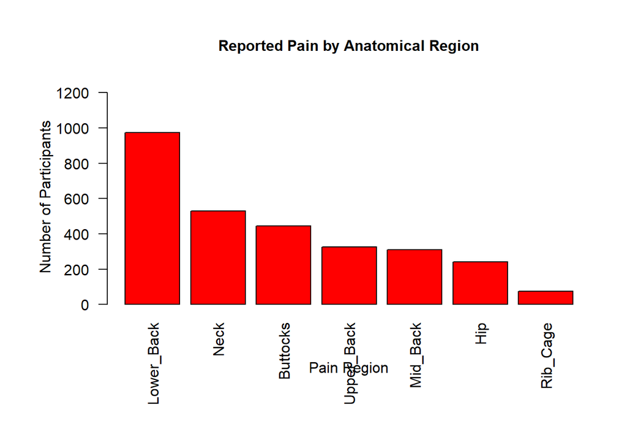

```r
pain_frequencies <- c(
  Neck = sum(yes_group$site_neck == TRUE, na.rm = TRUE),
  Upper_Back = sum(yes_group$site_upper_back == TRUE, na.rm = TRUE),
  Mid_Back = sum(yes_group$site_mid_back == TRUE, na.rm = TRUE),
  Lower_Back = sum(yes_group$site_low_back == TRUE, na.rm = TRUE),
  Buttocks = sum(yes_group$site_buttocks == TRUE, na.rm = TRUE),
  Hip = sum(yes_group$site_hip == TRUE, na.rm = TRUE),
  Rib_Cage = sum(yes_group$site_rib_cage == TRUE, na.rm = TRUE)
)

pain_frequencies <- sort(pain_frequencies, decreasing = TRUE)

par(mar = c(8, 6, 5, 2))

barplot(
  pain_frequencies,
  main = "Reported Pain by Anatomical Region",
  xlab = "Pain Region",
  ylab = "Number of Participants",
  col = "red",
  las = 2,
  ylim = c(0, max(pain_frequencies) * 1.25),
  cex.main = 1
)
```

This will help provide some descriptive context for upcoming studies, but as of now, knowing their particular frequencies isn’t a major concern.

What would be significant to observe, would be how many regions the participants are suffering prolonged pain or stiffness with. Perhaps a majority are actually pertaining to only one or all of them, and that would provide insights to gauge pain or stiffness coverage. The survey did permit participants to mark all that applied.

The following plot aims to outline how many regions participants reported to be suffering from:

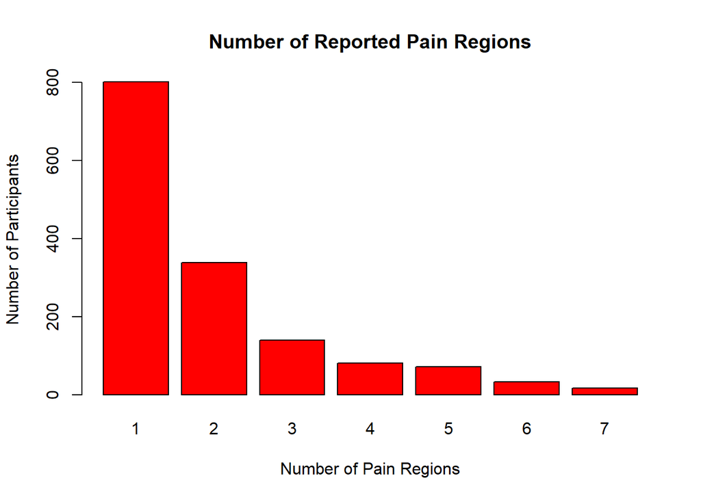

```r
pain_regions <- yes_group[, c(
  "site_neck",
  "site_upper_back",
  "site_mid_back",
  "site_low_back",
  "site_buttocks",
  "site_hip",
  "site_rib_cage"
)]

valid_regions <- pain_regions[complete.cases(pain_regions), ]
region_count <- rowSums(valid_regions)

region_frequencies <- table(region_count)

barplot(
  region_frequencies,
  main = "Number of Reported Pain Regions",
  xlab = "Number of Pain Regions",
  ylab = "Number of Participants",
  names.arg = names(region_frequencies),
  col = "red"
)
```

```r
region_frequencies <- table(region_count)
region_frequencies
```

```
## region_count
##   1   2   3   4   5   6   7
## 802 338 140  81  72  33  17
```

As for if this potentially represents the American population, we’d have to consider matters with variable weights and design adjustments if we were to make such a claim. The research question is particularly focused on NHANES participants, so that is a separate consideration.

## Physical Examination Comparisons for Prolonged One-Region Pain Participants

To connect the frequencies of prolonged region pain or suffering to their physical examinations, we’ll be examining the participants that suffer symptoms from only one region, instead of multiple.

We’ll split the 1-region participants based on what anatomical region they’re suffering in, and cross-compare their measurement statistics with boxplots. Considering prior observations with specific anatomical regions having differing magnitudes between ‘yes’ and ‘no’ groups, it’s also possible such logic may also extend to independent anatomical regions.

```r
valid_regions <- pain_regions[complete.cases(pain_regions), ]
region_count <- rowSums(valid_regions)
one_region <- valid_regions[region_count == 1, ]

region_names <- c(
  "Neck", "Upper back", "Mid back", "Lower back",
  "Buttocks", "Hip", "Rib cage"
)

one_region$only_region <- factor(
  region_names[max.col(as.matrix(one_region), ties.method = "first")],
  levels = region_names
)

table(one_region$only_region)
```

```
##
##       Neck Upper back   Mid back Lower back   Buttocks        Hip   Rib cage
##        135         42         32        410        101         69         13
```

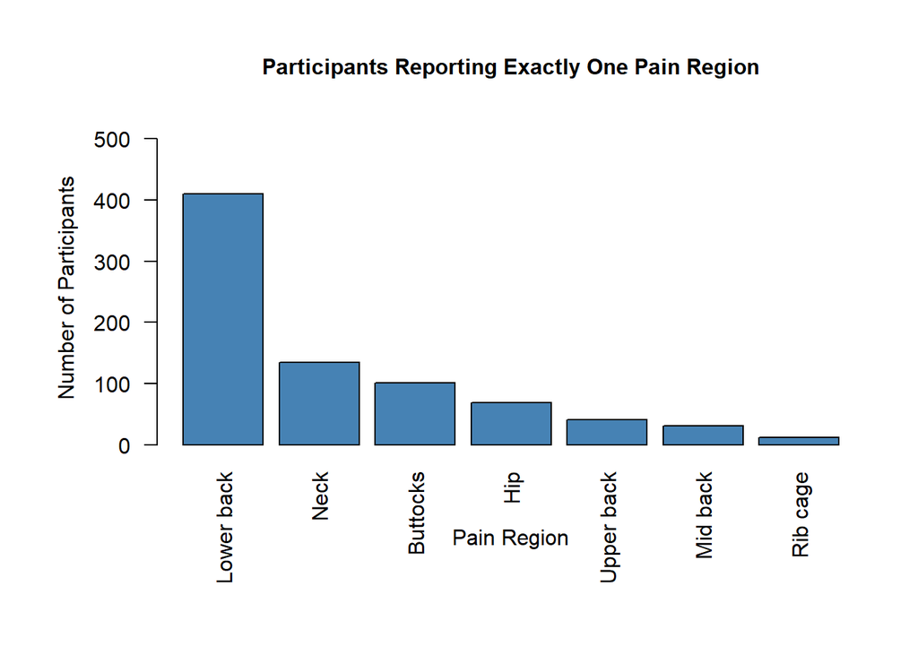

```r
single_region_freq <- table(one_region$only_region)
single_region_freq <- sort(single_region_freq, decreasing = TRUE)
par(mar = c(8, 6, 5, 2))

barplot(
  single_region_freq,
  main = "Participants Reporting Exactly One Pain Region",
  xlab = "Pain Region",
  ylab = "Number of Participants",
  col = "steelblue",
  las = 2,
  ylim = c(0, max(single_region_freq) * 1.25),
  cex.main = 1
)
```

From the bar plot (which to clarify, is not right skewed due to it being sorted), it’s noted that the dominant region of pain or stiffness amongst the 1-region participants is the lower back, followed by the neck, buttocks and hip. The other regions of the backs appear to be less common compared to specifically the lower back, so it would be better to treat the three regions of the back with specificity rather than unifying them as one singular region.

## Comparing Anatomic Regions: Physical Examination Measurements

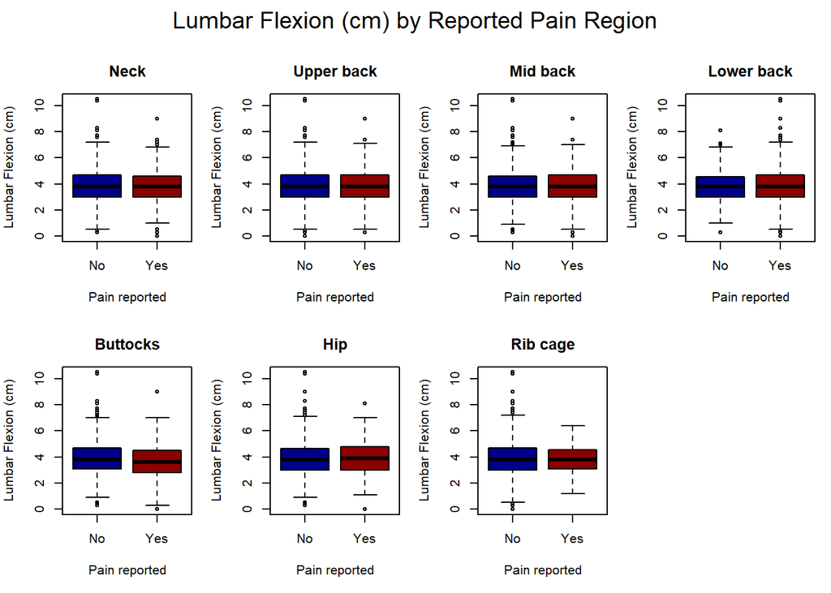

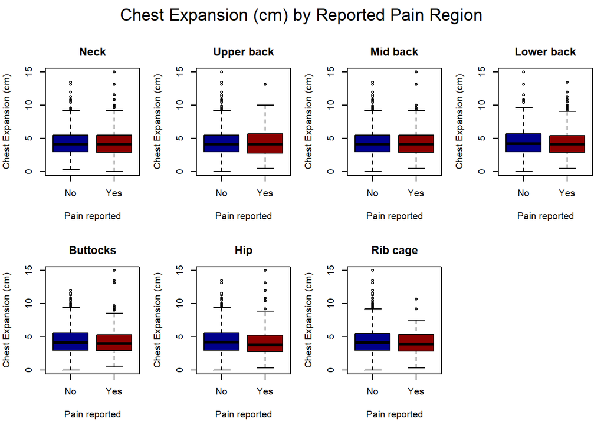

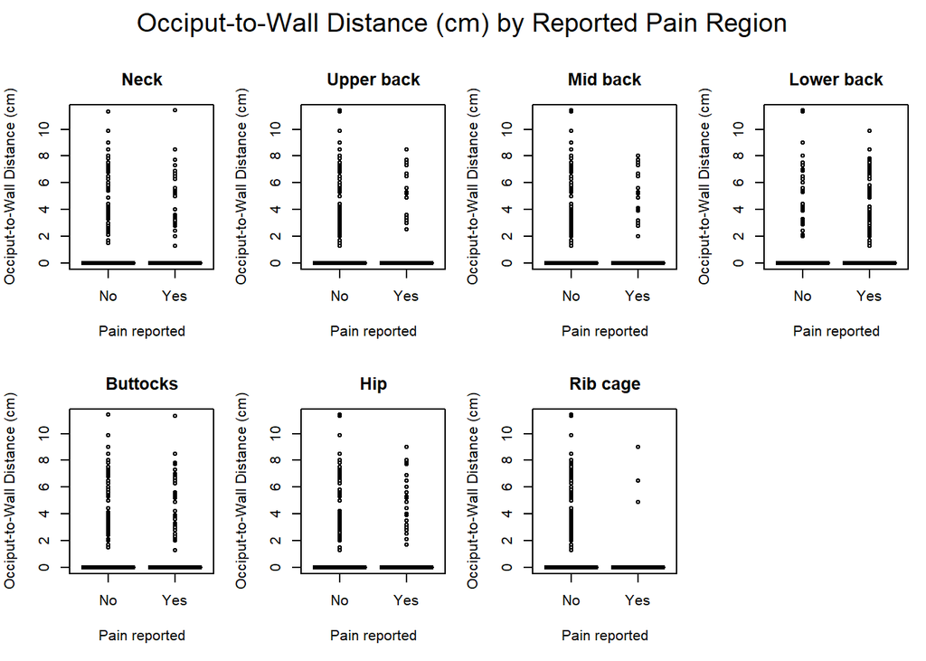

```r
regions <- c(
  "site_neck",
  "site_upper_back",
  "site_mid_back",
  "site_low_back",
  "site_buttocks",
  "site_hip",
  "site_rib_cage"
)

region_labels <- c(
  "Neck",
  "Upper back",
  "Mid back",
  "Lower back",
  "Buttocks",
  "Hip",
  "Rib cage"
)

measurements <- c(
  "lumbar_flexion_cm",
  "chest_expansion_cm",
  "occiput_wall_cm"
)

measurement_labels <- c(
  "Lumbar Flexion (cm)",
  "Chest Expansion (cm)",
  "Occiput-to-Wall Distance (cm)"
)

for (m in seq_along(measurements)) {

  par(
    mfrow = c(2, 4),
    mar = c(5, 4, 3, 1),
    oma = c(0, 0, 3, 0)
  )

  for (i in seq_along(regions)) {

    boxplot(
      yes_group[[measurements[m]]] ~ yes_group[[regions[i]]],
      main = region_labels[i],
      xlab = "Pain reported",
      ylab = measurement_labels[m],
      names = c("No", "Yes"),
      col = c("darkblue", "darkred")
    )
  }

  mtext(
    paste(measurement_labels[m], "by Reported Pain Region"),
    outer = TRUE,
    line = 1,
    cex = 1.2
  )
}
```

[output not shown]

Overall, most of the regions for lumbar flexion share the same similarities with little variation.

Chest Expansion

Compared to lumbar flexion, regions seem to have more distinguished variations for chest expansion, which may imply some form of association between chest expansion and the region of prolonged pain or stiffness. The lower-back, buttocks, hip and rib-cage comparisons have a lower average expansion among the ‘yes’ group.

Occiput-to-Wall Distance

- As with the original overall boxplot, the distributions are very right skewed, with the medians up against the left side of the distribution compared to the abundance of outliers in all plots. The outlier distributions and quantities do vary however, with regions like the upper and mid backs, hip and rib cage having differing ranges.
- Rib cage in particular has only a few outliers in its ‘yes’ group compared to the ‘no’ group, though this could be because it is the least frequent reported region for pain or stiffness.
- In most cases however, the ‘no’ group seems to have a simple majority in terms of outlier abundance.

It could be stated that there is variation between these regions for occiput-to-wall distance, but it would likely require a more precise approach with summaries and case-by-case counts. The median and IQR aren’t enough to properly distinguish all of these regions, so the differences within their tails may be more significant. We may also have to consider proportions instead of quantities.

For all of the regions presented, as well as the measurement explored, it’s noted that in most cases that differences between the ‘yes’ and ‘no’ groups are more pronounced as the frequency of participants in that region are lessened. The ‘yes’ groups appear to be smaller as the frequency of that particular region declines, making sample size a distinctive trait that puts to question differences anatomically.

Overall though, it is a considerable possibility that the boxplot results from these measurements may challenge the association of regional prolonged pain and stiffness with the results from physical examinations. A missing piece for understanding how these may pertain to one another, is by examining a portion of a dataset with a lack of prolonged pain or stiffness and their measurements. If the groups seem to have similar boxplots, the argument could be made that association may be inconclusive.

As of now, with these plots, mobility measurements are not clearly separated according to pain location, which does not support association. We can use mathematical approaches later on to verify if these interpretations are supported.

Everything here will be expanded on and further explored with more visualizations.

## SECTION 2

## Demographic Explanations for Differences in Reported Prolonged Pain or Stiffness and Measurements

Alongside investigating how the physical examinations may be associated with reported prolonged pain or stiffness, we’ll be exploring confounding demographic variables that may potentially yield stronger or challenging explanations for the relationships we discover in previous observations.

```r
head(clean_data[c("age_years", "bmi", "sex", "race_ethnicity")])
```

```
## # A tibble: 6 × 4
##   age_years   bmi sex    race_ethnicity
##       <dbl> <dbl> <fct>  <fct>
## 1        34  32.2 Male   Non-Hispanic White
## 2        60  42.4 Female Non-Hispanic Black
## 3        26  32.6 Male   Mexican American
## 4        49  30.6 Female Non-Hispanic White
## 5        42  39.9 Female Non-Hispanic Black
## 6        66  28.2 Male   Mexican American
```

As established before, the ages of the dataset range from 20-69.

We’ll be investigating BMI, sex and ethnicity as other explanatory variables alongside age, as well as seeing their general distributions.

```r
cat("Summary of Age\n")
```

```
## Summary of Age
```

```r
summary(clean_data$age_years)
```

```
##    Min. 1st Qu.  Median    Mean 3rd Qu.    Max.
##   20.00   32.00   44.00   43.83   56.00   69.00
```

```r
cat("Summary of BMI\n")
```

```
## Summary of BMI
```

```r
summary(clean_data$bmi)
```

```
##    Min. 1st Qu.  Median    Mean 3rd Qu.    Max.    NA's
##   15.02   24.44   28.19   29.29   32.84   84.87      39
```

```r
cat("Summary of Sex\n")
```

```
## Summary of Sex
```

```r
summary(clean_data$sex)
```

```
##   Male Female
##   2418   2583
```

```r
prop.table(table(clean_data$sex)) * 100
```

```
##
##     Male   Female
## 48.35033 51.64967
```

```r
cat("Summary of Race/Ethnicity\n")
```

```
## Summary of Race/Ethnicity
```

```r
summary(clean_data$race_ethnicity)
```

```
##      Mexican American        Other Hispanic    Non-Hispanic White
##                  1002                   560                  2206
##    Non-Hispanic Black Other or Multi-Racial
##                   944                   289
```

```r
prop.table(table(clean_data$race_ethnicity)) * 100
```

```
##
##      Mexican American        Other Hispanic    Non-Hispanic White
##             20.035993             11.197760             44.111178
##    Non-Hispanic Black Other or Multi-Racial
##             18.876225              5.778844
```

```r
sum(is.na(clean_data$age_years))
```

```
## [1] 0
```

```r
sum(is.na(clean_data$bmi))
```

```
## [1] 39
```

```r
sum(is.na(clean_data$sex))
```

```
## [1] 0
```

```r
sum(is.na(clean_data$race_ethnicity))
```

```
## [1] 0
```

## Age Distribution

```r
mean(clean_data$age_years, na.rm = TRUE)
```

```
## [1] 43.83303
```

```r
median(clean_data$age_years, na.rm = TRUE)
```

```
## [1] 44
```

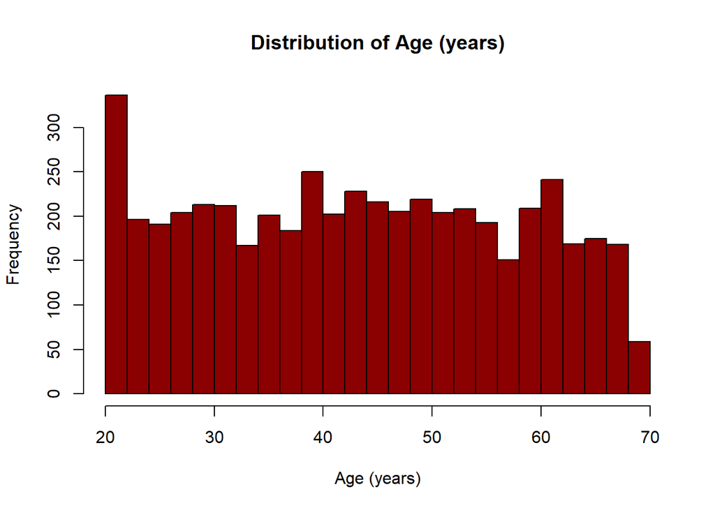

```r
plot_histogram(clean_data, "age_years", "Age (years)")
```

## BMI Distribution

```r
mean(clean_data$bmi, na.rm = TRUE)
```

```
## [1] 29.28915
```

```r
median(clean_data$bmi, na.rm = TRUE)
```

```
## [1] 28.19
```

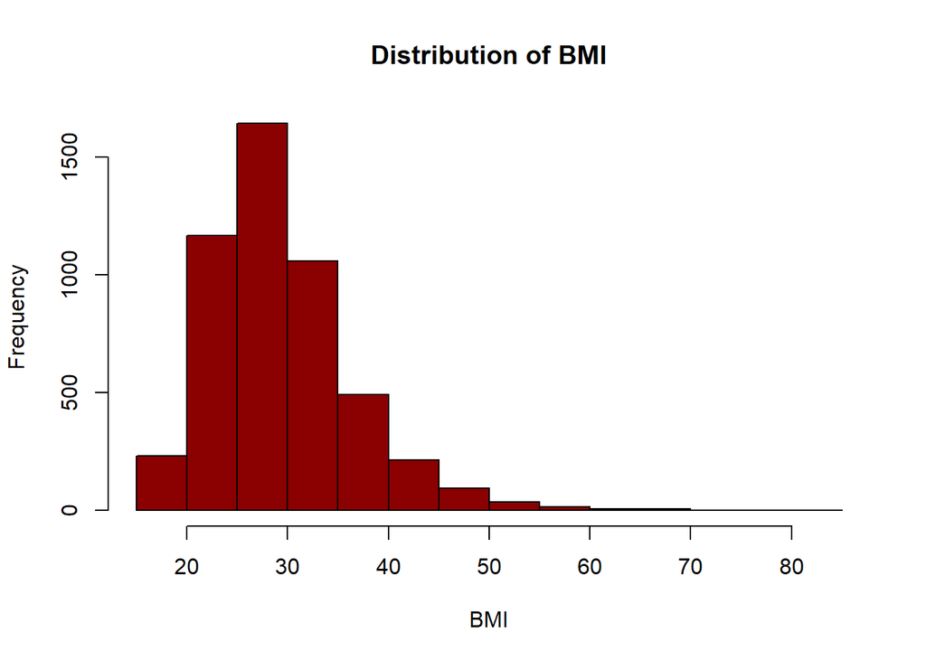

```r
plot_histogram(clean_data, "bmi", "BMI")
```

The average/mean BMI is about 29.29 while our median is 28.19. Our histogram shows the BMI Distribution of our participants, the frequency of participants in each BMI range. We can clearly see how this histogram is skewed right, with a bulk of our data concentrating around a BMI of 20-35, the participants aren’t restricted to a single bin range like standard, overweight or underweight. Some participants in particular are extreme outliers, numbering from 60 to 80, which may impose unique anomalies compared to the rest of the distribution.

## Sex Distribution

```r
get_category_info(clean_data, "sex")
```

```
## Category counts:
##
##   Male Female
##   2418   2583
##
## Category percentages:
##
##   Male Female
##   48.4   51.6
```

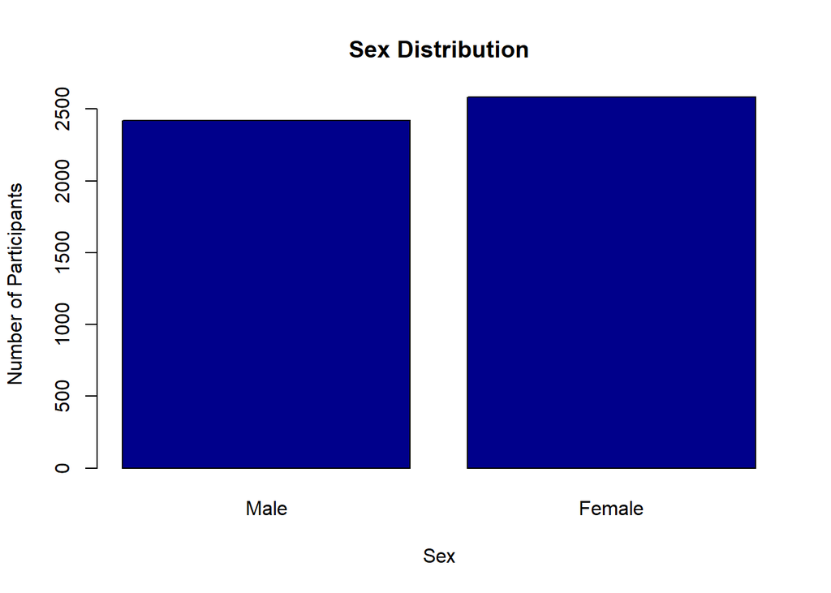

```r
plot_category_bar(clean_data, "sex", "Sex")
```

There are 2,418 male participants and 2,583 female participants. Both are almost equal, but females have 165 more participants than male participants. Because sex tends to be distinctive as a biological attribute, it may be worth separating the two for some analyses to see if they differ when it comes to questionnaire responses or physical examinations. They can still be studied as one sex-blind group, but it would be worth investigating differences.

## Race/Ethnicity Distribution

```r
get_category_info(clean_data, "race_ethnicity")
```

```
## Category counts:
##
##      Mexican American        Other Hispanic    Non-Hispanic White
##                  1002                   560                  2206
##    Non-Hispanic Black Other or Multi-Racial
##                   944                   289
##
## Category percentages:
##
##      Mexican American        Other Hispanic    Non-Hispanic White
##                  20.0                  11.2                  44.1
##    Non-Hispanic Black Other or Multi-Racial
##                  18.9                   5.8
```

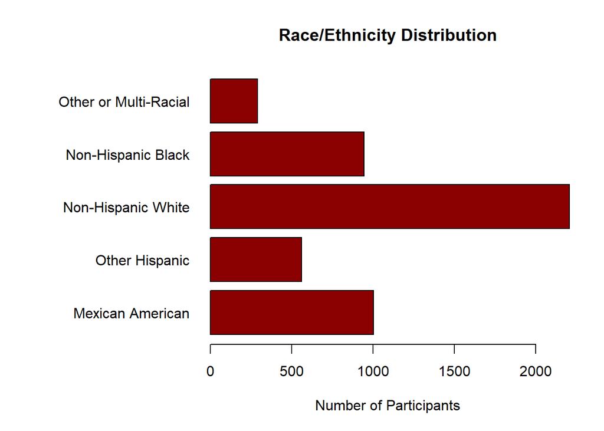

```r
plot_category_bar(clean_data, "race_ethnicity", "Race/Ethnicity", horizontal = TRUE)
```